# Skadefrekvens i bilforsikring

Poisson-GLM og gradient boosting på franske bilansvarsdata

Forfatter

Eirik Aarrestad

Utgitt

18. november 2026

**Kode**

```r
library(dplyr)
library(ggplot2)
library(knitr)

train <- readRDS("../data/train.rds")
test  <- readRDS("../data/test.rds")

theme_set(theme_minimal(base_size = 12))
fill_col <- "#3B7DB5"

# Tall med norsk desimalkomma og mellomrom som tusenskille
fmt <- function(x, digits = 3) {
  formatC(x, format = "f", digits = digits, decimal.mark = ",", big.mark = " ")
}
pct <- function(x, digits = 1) paste0(fmt(100 * x, digits), " %")

# Grupperte variabler (DrivAgeGrouped osv.) lages i R/01_load_data.R.
# Her justeres bare variabler for figurene.
train <- train |>
  mutate(
    VehPowerF = factor(VehPower),
    VehBrand = factor(VehBrand, levels = paste0("B", c(1:6, 10:14)))
  )

# Skadefrekvens: antall skader per forsikringsår
total_freq <- sum(train$ClaimNb) / sum(train$Exposure)

freq_table <- function(var) {
  train |>
    group_by({{ var }}) |>
    summarise(
      eksponering = sum(Exposure),
      skader = sum(ClaimNb),
      frekvens = skader / eksponering,
      .groups = "drop"
    )
}

# Søylediagram med total skadefrekvens som stiplet linje
plot_freq <- function(tab, var, xlab) {
  ggplot(tab, aes(x = {{ var }}, y = frekvens)) +
    geom_col(fill = fill_col) +
    geom_hline(yintercept = total_freq, linetype = "dashed") +
    labs(x = xlab, y = "Skader per forsikringsår")
}
```

## 1 Innledning

Et forsikringsselskap må sette en pris før det vet hvilke kunder som kommer til å melde skader. Den forventede kostnaden for en kunde deles vanligvis i to: hvor ofte kunden melder skader (*skadefrekvens*) og hvor mye hver skade koster (*skadestørrelse*). Prisen bygger på produktet av de to.

Dette prosjektet ser på den første delen. Målet er å forstå hvilke egenskaper ved fører, kjøretøy og bosted som påvirker hvor ofte det meldes skader, og å bygge en modell som kan predikere skadefrekvensen for nye kunder. Hovedmodellen er en Poisson-GLM, som er standardmetoden for frekvensmodellering i forsikringsbransjen. Den sammenlignes med gradient boosting (xgboost), en maskinlæringsmetode som selv finner ikke-lineære sammenhenger og samspill, for å se hva GLM-en eventuelt går glipp av.

Prosjektet bygger på casestudien til Noll, Salzmann og Wüthrich (2018), som bruker det samme datasettet.

## 2 Data

Datasettet `freMTPL2freq` fra R-pakken `CASdatasets` inneholder 677 991 franske bilansvarsforsikringer. Hver rad er én forsikring med antall meldte skader, hvor lenge forsikringen var aktiv, og egenskaper ved fører, kjøretøy og bosted.

| Variabel | Beskrivelse |
| --- | --- |
| `ClaimNb` | Antall meldte skader (responsvariabel) |
| `Exposure` | Hvor lenge forsikringen var aktiv, i år |
| `DrivAge` | Førerens alder |
| `BonusMalus` | Bonus/malus-nivå, fra 50 (full bonus) og oppover. 100 er startnivå, over 100 er malus |
| `VehAge` | Bilens alder i år |
| `VehPower` | Bilens effektklasse |
| `VehBrand` | Bilmerke (anonymisert) |
| `VehGas` | Drivstoff: diesel eller bensin |
| `Area` | Områdekode fra A til F |
| `Density` | Befolkningstetthet i førerens kommune (innbyggere per km²) |
| `Region` | Fransk region |

To variabler er kappet, som i Noll mfl. (2018): `Exposure` på 1 år, siden noen få verdier over 1 trolig er feil, og `ClaimNb` på 4 skader, siden høyere tall er svært sjeldne og trolig feilregistreringer. Se `R/01_load_data.R`.

Dataene er delt tilfeldig i et treningssett (80 %, 542 393 forsikringer) og et testsett (20 %, 135 598 forsikringer). All utforskning og modelltilpasning gjøres på treningssettet. Testsettet brukes bare til å evaluere de ferdige modellene, slik at evalueringen gir et ærlig bilde av hvor godt modellene fungerer på nye kunder.

## 3 Utforskende analyse

### 3.1 Skadeantall og eksponering

**Kode**

```r
train |>
  count(ClaimNb, name = "Antall forsikringer") |>
  mutate(Andel = pct(`Antall forsikringer` / sum(`Antall forsikringer`), 2),
         `Antall forsikringer` = fmt(`Antall forsikringer`, 0)) |>
  rename(`Antall skader` = ClaimNb) |>
  kable(align = "rrr")
```

Tabell 1: Fordeling av antall skader per forsikring i treningssettet.

| Antall skader | Antall forsikringer | Andel |
| --- | --- | --- |
| 0 | 522 429 | 96,32 % |
| 1 | 18 840 | 3,47 % |
| 2 | 1 066 | 0,20 % |
| 3 | 48 | 0,01 % |
| 4 | 10 | 0,00 % |

Skader er sjeldne. 96,3 % av forsikringene har ingen skader, og bare 0,21 % har to eller flere (Tabell 1). Responsvariabelen er altså et lite heltall som oftest er 0, noe som passer godt med en Poisson-fordeling.

**Kode**

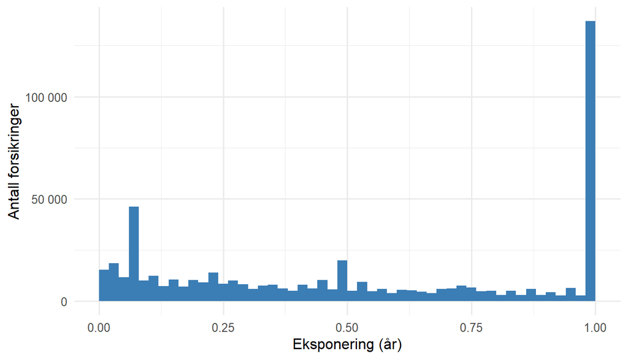

Figur 1: Fordeling av eksponering. Mange forsikringer har vært aktive i et helt år, men en stor andel bare deler av året.

```r
ggplot(train, aes(Exposure)) +
  geom_histogram(binwidth = 0.02, boundary = 0, fill = fill_col) +
  scale_y_continuous(labels = function(x) fmt(x, 0)) +
  labs(x = "Eksponering (år)", y = "Antall forsikringer")
```

Bare 25,0 % av forsikringene har vært aktive i et helt år (Figur 1). Resten har vært aktive i kortere tid, for eksempel fordi kunden kom til eller sluttet i løpet av året. Dette må tas hensyn til: en kunde som har vært forsikret i en måned, har hatt mye kortere tid på seg til å melde en skade enn en som har vært forsikret i et år.

Derfor måles skadefrekvens i denne rapporten som antall skader per forsikringsår:

$$\hat\lambda = \frac{\sum_i N_i}{\sum_i e_i},$$

der $N_i$ er antall skader og $e_i$ eksponeringen for forsikring $i$. Gjennomsnittet av `ClaimNb` ville undervurdert frekvensen, fordi mange forsikringer bare har vært aktive en del av året. Total skadefrekvens i treningssettet er 0,074 skader per forsikringsår. I modellene tas eksponeringen inn som et *offset*.

I figurene under viser den stiplede linjen den totale skadefrekvensen.

### 3.2 Føreren: alder og bonus/malus

**Kode**

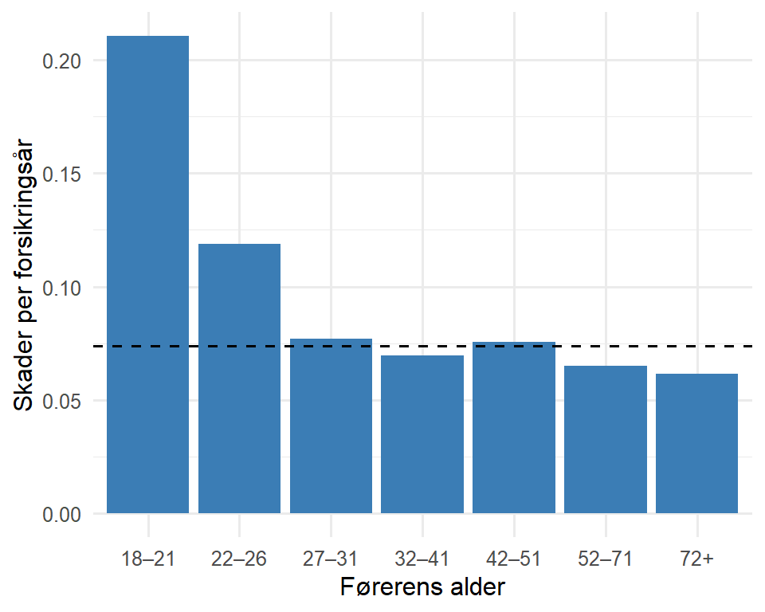

(a) Førerens alder

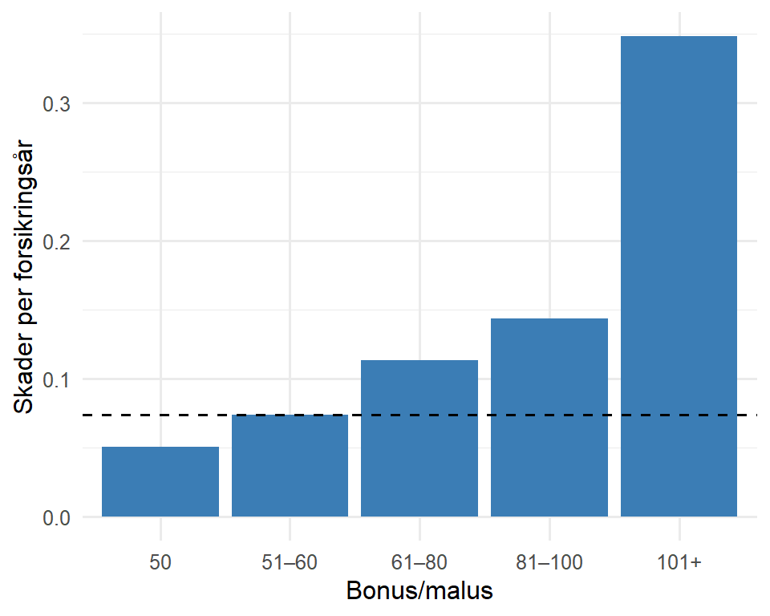

(b) Bonus/malus

Figur 2: Skadefrekvens etter førerens alder og bonus/malus-nivå.

```r
tab_age <- freq_table(DrivAgeGrouped)
tab_bm  <- freq_table(BonusMalusGrouped)

plot_freq(tab_age, DrivAgeGrouped, "Førerens alder")
plot_freq(tab_bm, BonusMalusGrouped, "Bonus/malus")
```

**Kode**

```r
young   <- tab_age$frekvens[tab_age$DrivAgeGrouped == "18–21"]
middle  <- tab_age$frekvens[tab_age$DrivAgeGrouped == "32–41"]
bm_full <- tab_bm$frekvens[tab_bm$BonusMalusGrouped == "50"]
bm_high <- tab_bm$frekvens[tab_bm$BonusMalusGrouped == "101+"]
```

Førerens alder og bonus/malus er de to variablene med tydeligst sammenheng med skadefrekvensen (Figur 2).

- **Alder:** Førere mellom 18 og 21 år har en skadefrekvens på 0,210, omtrent 3,0 ganger så høy som førere mellom 32 og 41 år (0,069). Frekvensen faller raskt frem til slutten av 20-årene og er deretter nokså flat. Sammenhengen er altså ikke lineær.
- **Bonus/malus:** Frekvensen øker jevnt med bonus/malus-nivået. Førere med malus (over 100) har en frekvens på 0,348, omtrent 6,8 ganger så høy som førere med full bonus (0,051). Det er ventet, siden bonus/malus-nivået nettopp bygger på tidligere skader.

De to variablene henger sammen. I det franske bonus/malus-systemet starter nye førere på 100, og nivået synker for hvert skadefritt år. Unge førere har derfor høyere bonus/malus i snitt (Tabell 2).

**Kode**

```r
train |>
  group_by(`Førerens alder` = DrivAgeGrouped) |>
  summarise(
    `Snitt bonus/malus` = fmt(mean(BonusMalus), 1),
    `Andel med malus (over 100)` = pct(mean(BonusMalus > 100)),
    .groups = "drop"
  ) |>
  kable(align = "lrr")
```

Tabell 2: Bonus/malus etter førerens alder.

| Førerens alder | Snitt bonus/malus | Andel med malus (over 100) |
| --- | --- | --- |
| 18–21 | 94,5 | 7,8 % |
| 22–26 | 84,9 | 6,2 % |
| 27–31 | 71,5 | 2,1 % |
| 32–41 | 60,2 | 0,9 % |
| 42–51 | 54,8 | 0,4 % |
| 52–71 | 53,5 | 0,4 % |
| 72+ | 52,4 | 0,3 % |

Det betyr at figurene over delvis viser den samme effekten to ganger: noe av den høye frekvensen blant unge førere skyldes at de også har høy bonus/malus, og omvendt. Søylediagrammer viser bare én variabel om gangen og kan ikke skille effektene fra hverandre. Det kan en modell med begge variablene samtidig, som GLM-en i neste del.

### 3.3 Bosted: områdekode og befolkningstetthet

**Kode**

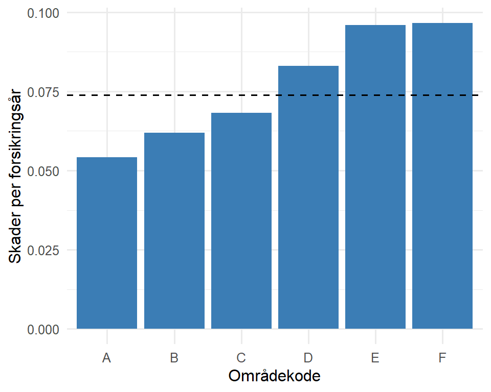

(a) Områdekode

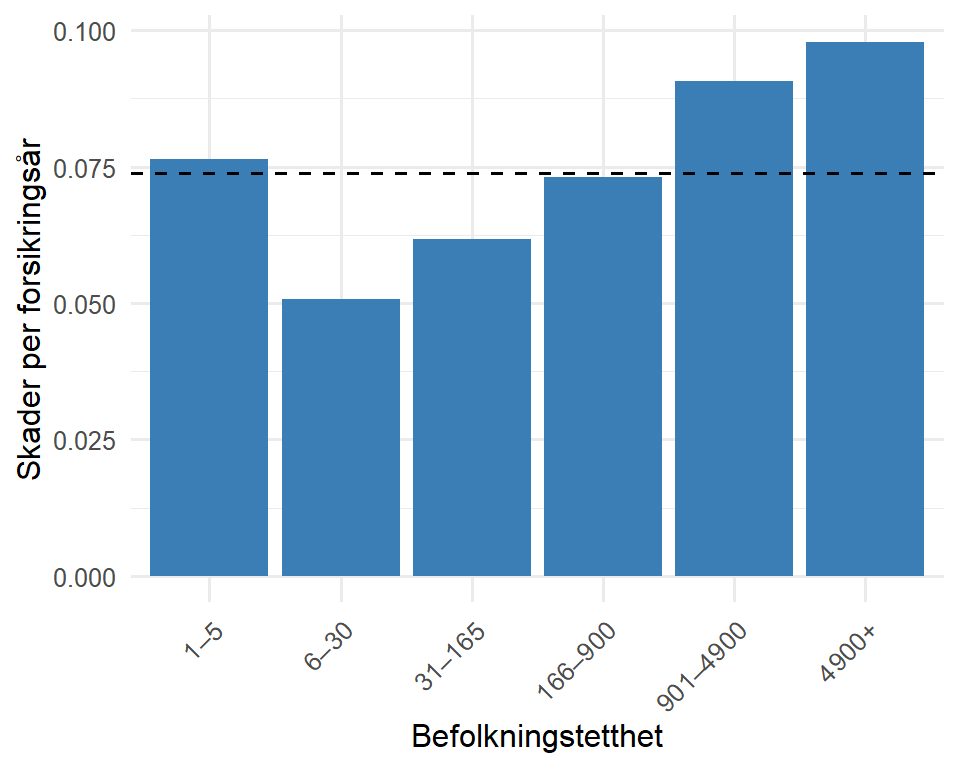

(b) Befolkningstetthet (innbyggere per km²)

Figur 3: Skadefrekvens etter områdekode og befolkningstetthet.

```r
plot_freq(freq_table(Area), Area, "Områdekode")
plot_freq(freq_table(DensityGrouped), DensityGrouped, "Befolkningstetthet") +
  theme(axis.text.x = element_text(angle = 45, hjust = 1))
```

Skadefrekvensen øker fra område A til F, og stort sett også med befolkningstettheten (Figur 3). Det gir mening: i tettbygde strøk er det mer trafikk og flere situasjoner der skader kan oppstå. Unntaket er de mest grisgrendte kommunene (1–5 innbyggere per km²), som har høyere frekvens enn neste gruppe.

**Kode**

```r
train |>
  group_by(`Områdekode` = Area) |>
  summarise(
    `Median tetthet` = fmt(median(Density), 0),
    `Antall forsikringer` = fmt(n(), 0),
    .groups = "drop"
  ) |>
  kable(align = "lrr")
```

Tabell 3: Befolkningstetthet etter områdekode.

| Områdekode | Median tetthet | Antall forsikringer |
| --- | --- | --- |
| A | 27 | 83 134 |
| B | 72 | 60 483 |
| C | 222 | 153 362 |
| D | 1 054 | 121 082 |
| E | 3 744 | 109 939 |
| F | 27 000 | 14 393 |

Områdekoden og tettheten måler nesten det samme: medianen for tettheten øker jevnt fra A til F (Tabell 3). Å ta med begge i samme modell gir lite ny informasjon og gjør koeffisientene vanskeligere å tolke. I modellen brukes derfor bare én av dem.

### 3.4 Kjøretøyet

**Kode**

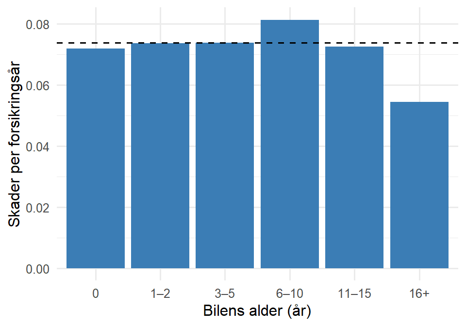

(a) Bilens alder (år)

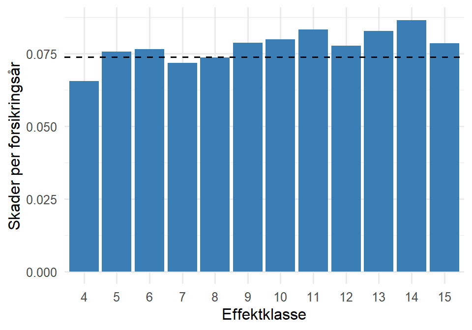

(b) Effektklasse

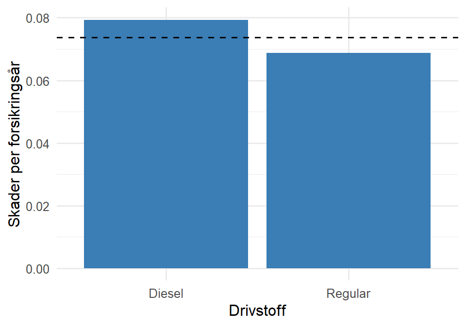

(c) Drivstoff

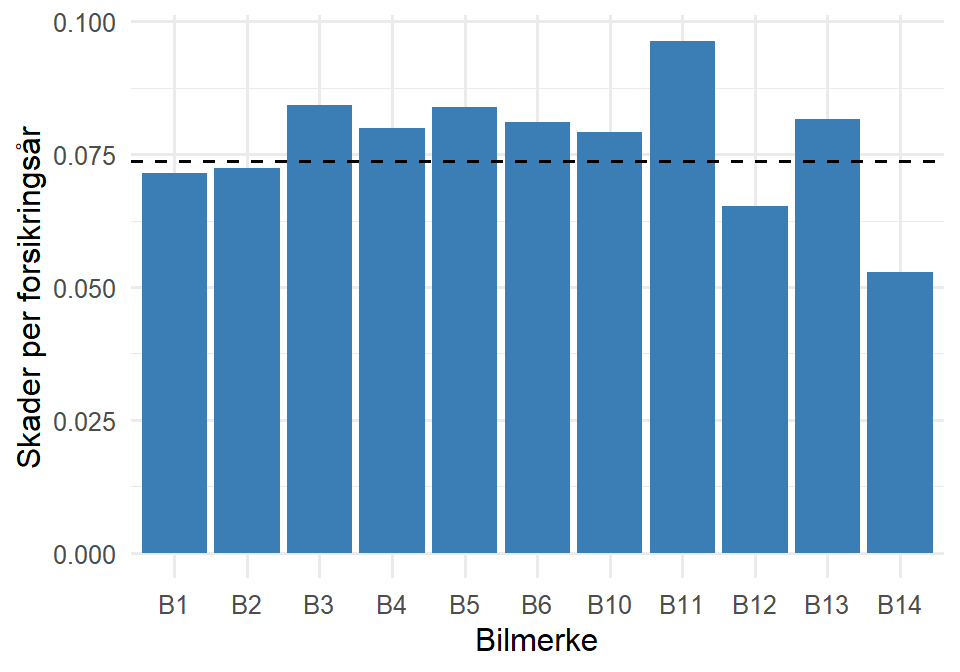

(d) Bilmerke

Figur 4: Skadefrekvens etter egenskaper ved kjøretøyet.

```r
tab_brand <- freq_table(VehBrand)

plot_freq(freq_table(VehAgeGrouped), VehAgeGrouped, "Bilens alder (år)")
plot_freq(freq_table(VehPowerF), VehPowerF, "Effektklasse")
plot_freq(freq_table(VehGas), VehGas, "Drivstoff")
plot_freq(tab_brand, VehBrand, "Bilmerke")
```

Kjøretøyvariablene har svakere sammenheng med skadefrekvensen enn førervariablene (Figur 4):

- **Bilens alder:** Frekvensen er nokså lik for biler opp til 15 år, men lavere for eldre biler. En mulig forklaring er at eldre biler kjøres mindre.
- **Effektklasse:** Svak tendens til høyere frekvens for kraftigere biler.
- **Drivstoff:** Dieselbiler har litt høyere frekvens enn bensinbiler, kanskje fordi dieselbiler ofte brukes av dem som kjører mye.
- **Bilmerke:** Frekvensen varierer fra 0,053 (B14) til 0,096 (B11). Merkene er anonymisert, så forskjellene er vanskelige å tolke.

### 3.5 Region

**Kode**

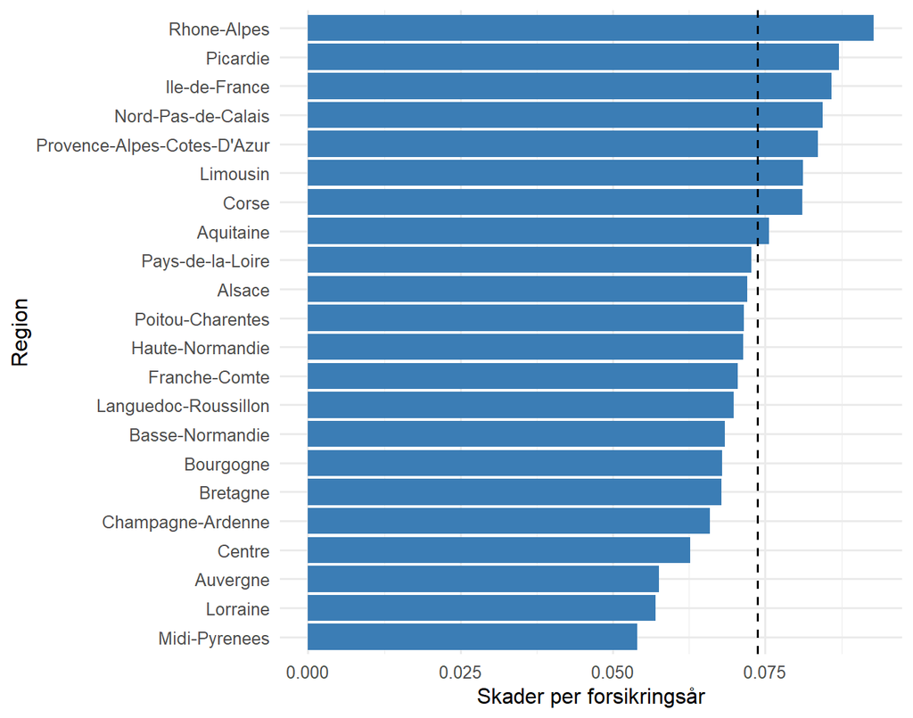

Figur 5: Skadefrekvens etter region, sortert.

```r
tab_reg <- freq_table(Region) |>
  mutate(Region = reorder(Region, frekvens))

plot_freq(tab_reg, Region, "Region") +
  coord_flip()
```

Skadefrekvensen varierer mellom regionene, fra 0,054 i Midi-Pyrenees til 0,093 i Rhone-Alpes (Figur 5). Noe av forskjellen henger trolig sammen med befolkningstetthet, siden regioner med store byer ligger høyt.

### 3.6 Oppsummering

Analysen gir fire føringer for modelleringen:

1. **Eksponeringen må tas med** som offset, siden forsikringene har vært aktive i ulik tid.
2. **Sammenhengene er ikke lineære**, særlig for alder. Alder, bilens alder og bonus/malus tas derfor inn som grupperte variabler.
3. **Alder og bonus/malus overlapper.** En modell med flere variabler samtidig trengs for å skille effektene.
4. **Områdekode og tetthet måler nesten det samme**, så bare én av dem tas med.

## 4 Metode

**Kode**

```r
glm_res <- readRDS("../output/glm_results.rds")
rr  <- glm_res$relative_risk
res <- glm_res$results

var_labels <- c(
  DrivAgeGrouped = "Førerens alder", BonusMalusGrouped = "Bonus/malus",
  VehAgeGrouped = "Bilens alder", VehPowerF = "Effektklasse",
  VehGas = "Drivstoff", VehBrand = "Bilmerke",
  DensityGrouped = "Befolkningstetthet", Region = "Region"
)

# Relativ risiko med konfidensintervall for ett nivå, f.eks. "1,17 (1,07–1,27)"
get_rr <- function(v, l) rr[rr$variable == v & rr$level == l, ]
fmt_rr <- function(r) {
  paste0(fmt(r$rr, 2), " (", fmt(r$lower, 2), "–", fmt(r$upper, 2), ")")
}
ref_level <- function(v) rr$level[rr$variable == v & rr$reference]
```

### 4.1 Poisson-GLM

Antall skader $N_i$ for forsikring $i$ modelleres som Poisson-fordelt med forventning lik skadefrekvensen $\lambda_i$ ganget med eksponeringen $e_i$:

$$N_i \sim \text{Poisson}(\lambda_i e_i), \qquad \log \lambda_i = \beta_0 + \sum_j \beta_j x_{ij}.$$

Det gir

$$\log \mathbb{E}[N_i] = \log e_i + \beta_0 + \sum_j \beta_j x_{ij},$$

der $\log e_i$ er et *offset*: et ledd med koeffisient fast lik 1. Slik tar modellen hensyn til at forsikringene har vært aktive i ulik tid, uten at eksponeringen behandles som en forklaringsvariabel.

Med log-lenke blir effektene multiplikative:

$$\lambda_i = e^{\beta_0} \prod_j e^{\beta_j x_{ij}}.$$

$e^{\beta_j}$ er den *relative risikoen*: hvor mye høyere eller lavere skadefrekvensen er i en gruppe sammenlignet med referansegruppen, når de andre variablene holdes like. En relativ risiko på 1,5 betyr 50 % høyere frekvens. Den multiplikative strukturen er også grunnen til at GLM er så utbredt i forsikringsprising: prisen kan uttrykkes som en grunnpris ganget med én faktor per kjennetegn.

### 4.2 Variabler

Alder, bilens alder, bonus/malus og befolkningstetthet tas inn som grupperte variabler, siden EDA-en viste at sammenhengene ikke er lineære. Effektklasse tas inn som kategorisk variabel. Områdekoden er utelatt, siden den måler nesten det samme som tettheten.

To grupper med svært få forsikringer er slått sammen, fordi de fikk veldig brede konfidensintervaller i en første tilpasning: tetthet 1–5 er slått sammen med 6–30, og effektklasse 12–15 er slått sammen til «12+».

For hver variabel er referansegruppen den med størst eksponering. Konstantleddet $e^{\beta_0}$ er da skadefrekvensen for en kunde i alle referansegruppene: 0,050 skader per år.

### 4.3 Modeller

Tre modeller sammenlignes:

1. **Nullmodell:** bare konstantledd, altså samme frekvens for alle. Den er sammenligningsgrunnlaget.
2. **Førervariabler:** alder og bonus/malus.
3. **Full GLM:** alle variablene over.

I tillegg sammenlignes den fulle GLM-en med en gradient boosting-modell med de samme variablene (se under).

### 4.4 Overdispersjon

Poisson-fordelingen har varians lik forventning. Hvis variansen i dataene er større, er det *overdispersjon*. Koeffisientene er fortsatt forventningsrette, men standardfeilene blir for små, og konfidensintervallene for smale.

Dispersjonen anslås som $\hat\phi = \frac{1}{n - p} \sum_i r_i^2$, der $r_i$ er Pearson-residualene og $p$ antall parametere. Konfidensintervaller og tester er beregnet med en quasi-Poisson-modell, som antar $\text{Var}(N_i) = \phi \, \mathbb{E}[N_i]$. Den gir de samme koeffisientene som Poisson-modellen, men skalerer standardfeilene med $\sqrt{\hat\phi}$. Bidraget fra hver variabel testes med en F-test, quasi-Poisson-versjonen av likelihood ratio-testen.

### 4.5 Gradient boosting

Som sammenligning tilpasses en gradient boosting-modell (GBM) med pakken `xgboost` (Chen og Guestrin, 2016). En GBM er en sum av mange små regresjonstrær, der hvert nye tre tilpasses slik at det retter opp feilene til trærne før (Friedman, 2001). Modellen bruker samme Poisson-likelihood, log-lenke og offset som GLM-en:

$$\log \mathbb{E}[N_i] = \log e_i + \sum_{k=1}^{K} f_k(\mathbf{x}_i),$$

der hver $f_k$ er et tre. Forskjellen er at modellen ikke antar at effektene er lineære i de grupperte variablene, eller at de ganges sammen uavhengig av hverandre. Et tre med dybde $d$ kan fange opp samspill mellom opptil $d$ variabler. Derfor brukes de rå variablene i stedet for de grupperte, slik at trærne selv finner hvor det er naturlig å dele.

Tredybde (2–5) og antall trær velges med 5-fold kryssvalidering på treningssettet. Antall trær velges med *early stopping*: det legges til trær helt til valideringsfeilen ikke har blitt bedre på 50 runder. Læringsraten er 0,05, og hvert tre bygges på et tilfeldig utvalg av 80 % av radene og variablene, noe som gjør modellen mindre utsatt for overtilpasning. Testsettet brukes ikke i tuningen, så sammenligningen med GLM-en på testdata er rettferdig.

Prisen for fleksibiliteten er at modellen ikke har koeffisienter som kan leses direkte. Den tolkes i stedet med to verktøy:

- **Variabelviktighet (gain):** hvor mye hver variabel totalt forbedrer tapsfunksjonen i splittene der den brukes.
- **Partial dependence:** gjennomsnittlig predikert frekvens når én variabel settes til samme verdi for alle kundene, mens de andre variablene beholder sine faktiske verdier (Friedman, 2001). Det gir en kurve som kan sammenlignes med de relative risikoene fra GLM-en. Kurvene er beregnet på et tilfeldig utvalg av 10 000 forsikringer fra treningssettet.

### 4.6 Evaluering

Modellene evalueres på testsettet med gjennomsnittlig Poisson-devians:

$$D = \frac{2}{n} \sum_{i=1}^{n} \left[ N_i \log \frac{N_i}{\hat\mu_i} - (N_i - \hat\mu_i) \right],$$

der $\hat\mu_i$ er predikert antall skader og $0 \log 0 = 0$. Devians er det naturlige målet for Poisson-data, og lavere er bedre. I tillegg sjekkes *kalibreringen*: om predikert antall skader stemmer med observert, totalt og per gruppe. For prising er det minst like viktig, siden en modell som treffer feil nivå gir feil pris for hele porteføljen.

## 5 Resultater

### 5.1 Modellsammenligning

**Kode**

```r
res |>
  transmute(
    Modell = modell,
    Parametere = parametere,
    AIC = fmt(aic, 0),
    `Devians trening` = fmt(dev_train, 4),
    `Devians test` = fmt(dev_test, 4),
    Forbedring = ifelse(forbedring == 0, "–", pct(forbedring))
  ) |>
  kable(align = "lrrrrr")
```

Tabell 4: Sammenligning av modellene. Devians er gjennomsnittlig Poisson-devians. Forbedringen er reduksjonen i devians på testdata sammenlignet med nullmodellen.

| Modell | Parametere | AIC | Devians trening | Devians test | Forbedring |
| --- | --- | --- | --- | --- | --- |
| Nullmodell | 1 | 177 760 | 0,2528 | 0,2522 | – |
| Førervariabler | 11 | 172 148 | 0,2424 | 0,2427 | 3,8 % |
| Full GLM | 60 | 171 082 | 0,2403 | 0,2407 | 4,6 % |

**Kode**

```r
improvement  <- res$forbedring[res$modell == "Full GLM"]
share_driver <- (res$dev_test[1] - res$dev_test[2]) /
                (res$dev_test[1] - res$dev_test[3])
```

Den fulle modellen reduserer devians på testdata med 4,6 % sammenlignet med nullmodellen (Tabell 4). Omtrent 83 % av forbedringen kommer fra alder og bonus/malus alene. Devians er nesten lik på trening og test, så modellen er ikke overtilpasset.

En forbedring på noen få prosent kan virke lite, men er typisk for skadefrekvens. Om en enkelt kunde melder en skade akkurat i år, er i stor grad tilfeldig, og den delen av variasjonen kan ingen modell forklare. Det modellen kan, er å skille grupper med høy og lav forventet frekvens, og det er det prisingen trenger.

### 5.2 Hvilke variabler betyr mest?

**Kode**

```r
ft <- glm_res$f_tests
dev_full <- ft$Deviance[1]
ft <- ft[-1, ]

data.frame(
  Variabel = unname(var_labels[rownames(ft)]),
  Frihetsgrader = ft$Df,
  `Økning i devians` = fmt(ft$Deviance - dev_full, 0),
  `F-verdi` = fmt(ft[["F value"]], 1),
  `p-verdi` = format.pval(ft[["Pr(>F)"]], digits = 2, eps = 1e-16),
  check.names = FALSE
)[order(-ft[["F value"]]), ] |>
  kable(row.names = FALSE, align = "lrrrr")
```

Tabell 5: F-test for hver variabel: hvor mye dårligere modellen blir når variabelen fjernes. Sortert etter F-verdi.

| Variabel | Frihetsgrader | Økning i devians | F-verdi | p-verdi |
| --- | --- | --- | --- | --- |
| Bonus/malus | 4 | 4 199 | 4 368,5 | <1e-16 |
| Førerens alder | 6 | 743 | 515,5 | <1e-16 |
| Drivstoff | 1 | 109 | 454,3 | <1e-16 |
| Befolkningstetthet | 4 | 235 | 244,2 | <1e-16 |
| Bilens alder | 5 | 195 | 162,5 | <1e-16 |
| Bilmerke | 10 | 199 | 83,0 | <1e-16 |
| Effektklasse | 8 | 99 | 51,4 | <1e-16 |
| Region | 21 | 147 | 29,1 | <1e-16 |

Bonus/malus er den klart viktigste variabelen, etterfulgt av førerens alder (Tabell 5). Alle variablene bidrar signifikant, også etter justering for overdispersjon. Med over en halv million observasjoner blir imidlertid selv små effekter signifikante, så størrelsen på effektene er mer interessant enn p-verdiene.

### 5.3 Relative risikoer

**Kode**

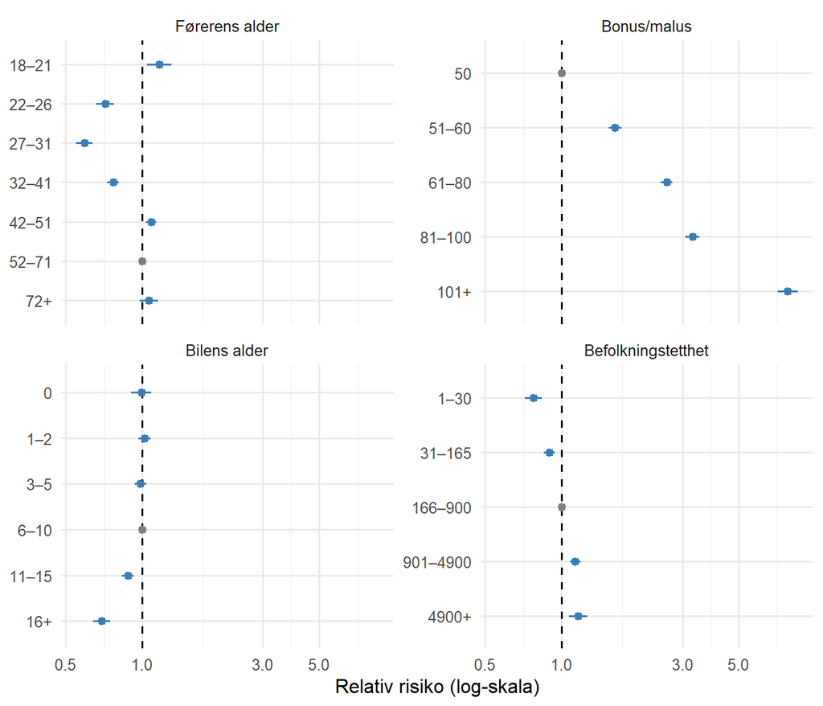

Figur 6: Relative risikoer med 95 % konfidensintervall, sammenlignet med referansegruppen (relativ risiko 1, stiplet linje). Logaritmisk skala.

```r
rr_plot <- rr |>
  filter(variable %in% c("DrivAgeGrouped", "BonusMalusGrouped", "VehAgeGrouped", "DensityGrouped")) |>
  mutate(
    variable = factor(var_labels[variable],
                      levels = var_labels[c("DrivAgeGrouped", "BonusMalusGrouped",
                                            "VehAgeGrouped", "DensityGrouped")]),
    id = paste0(variable, ":", level),
    id = factor(id, levels = rev(unique(id)))
  )

ggplot(rr_plot, aes(x = rr, y = id, xmin = lower, xmax = upper)) +
  geom_vline(xintercept = 1, linetype = "dashed") +
  geom_pointrange(aes(colour = reference), size = 0.3) +
  scale_colour_manual(values = c("FALSE" = fill_col, "TRUE" = "grey50"),
                      guide = "none") +
  scale_x_log10() +
  scale_y_discrete(labels = function(x) sub(".*:", "", x)) +
  facet_wrap(~ variable, scales = "free_y", ncol = 2) +
  labs(x = "Relativ risiko (log-skala)", y = NULL)
```

**Kode**

```r
age_rr   <- rr[rr$variable == "DrivAgeGrouped", ]
lowest   <- age_rr[which.min(age_rr$rr), ]
dens_rr  <- rr[rr$variable == "DensityGrouped", ]
brand_rr <- rr[rr$variable == "VehBrand" & !rr$reference, ]
reg_rr   <- rr[rr$variable == "Region" & !rr$reference, ]
```

**Alder.** Det viktigste funnet er at aldersmønsteret endrer seg når bonus/malus er med i modellen (Figur 6). I EDA-en hadde førere på 18–21 år over tre ganger så høy skadefrekvens som eldre førere. I modellen er den relative risikoen for 18–21 år bare 1,17 (1,05–1,31), sammenlignet med referansegruppen 52–71 år. Grunnen er overlappen fra EDA-en: unge førere starter på bonus/malus 100, så det meste av risikoen deres forklares allerede av bonus/malus-nivået.

Lavest risiko, gitt bonus/malus, har førere på 27–31 år, med relativ risiko 0,59 (0,55–0,64). En mulig forklaring er at bonus/malus betyr ulike ting i ulike aldre. En fører i slutten av 20-årene har ikke hatt tid til å opparbeide full bonus, selv uten skader, mens en eldre fører med samme nivå sannsynligvis har hatt skader. Effekten av alder avhenger altså av bonus/malus-nivået. Det er en *samspillseffekt*, som modellen ikke fanger opp, siden den antar at effektene ganges sammen uavhengig av hverandre.

**Bilens alder og tetthet.** Biler eldre enn 15 år har 31 % lavere risiko enn biler på 6–10 år, med relativ risiko 0,69 (0,64–0,75). Risikoen øker jevnt med befolkningstettheten, fra 0,77 i de mest grisgrendte kommunene til 1,16 i de tetteste. Toppen for de mest grisgrendte kommunene i EDA-en forsvant: gruppen var så liten at den ga et svært bredt intervall, og den er slått sammen med neste gruppe.

**Andre variabler.** Dieselbiler har relativ risiko 1,17 (1,13–1,22) sammenlignet med bensin, og effektklasse 12 eller høyere 1,18 (1,04–1,34) sammenlignet med klasse 6. For bilmerke varierer den relative risikoen fra 0,76 til 1,21, og for region fra 0,81 til 1,38. Mange av regioneffektene har brede intervaller som inkluderer 1.

### 5.4 Overdispersjon

Den anslåtte dispersjonen er $\hat\phi =$ 1,72. Variansen i dataene er altså omtrent 72 % større enn Poisson-modellen antar, og standardfeilene fra en vanlig Poisson-modell ville vært omtrent 1,31 ganger for små. Konfidensintervallene og testene over er justert for dette med quasi-Poisson. Overdispersjonen tyder på at det finnes variasjon mellom kundene som variablene ikke fanger opp, for eksempel hvor mye kunden kjører.

### 5.5 Kalibrering

**Kode**

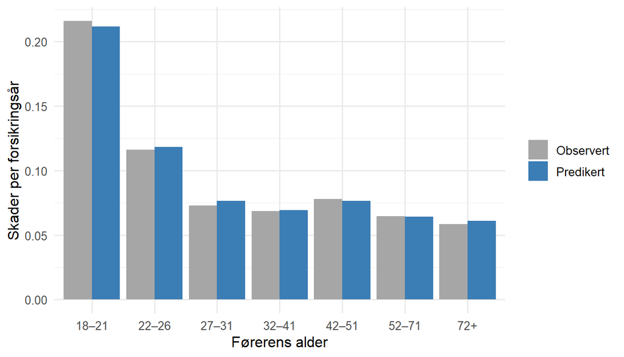

Figur 7: Observert og predikert skadefrekvens på testdata, etter førerens alder.

```r
cal <- glm_res$calibration$age
age_levels <- levels(train$DrivAgeGrouped)

cal_long <- data.frame(
  alder = factor(rep(cal$level, 2), levels = age_levels),
  type = rep(c("Observert", "Predikert"), each = nrow(cal)),
  frekvens = c(cal$observert, cal$predikert)
)

ggplot(cal_long, aes(x = alder, y = frekvens, fill = type)) +
  geom_col(position = "dodge") +
  scale_fill_manual(values = c("Observert" = "grey65", "Predikert" = fill_col)) +
  labs(x = "Førerens alder", y = "Skader per forsikringsår", fill = NULL)
```

Modellen predikerer 5 260 skader i testsettet, mot 5 249 observerte, et avvik på 0,2 %. Den treffer også godt innenfor hver aldersgruppe (Figur 7), inkludert de unge førerne, der dataene er minst.

### 5.6 Sammenligning med gradient boosting

**Kode**

```r
gbm_res <- readRDS("../output/gbm_results.rds")
gbm_row <- gbm_res$results
glm_row <- res[res$modell == "Full GLM", ]

gbm_labels <- c(
  DrivAge = "Førerens alder", BonusMalus = "Bonus/malus",
  VehAge = "Bilens alder", VehPower = "Effektklasse",
  VehGas = "Drivstoff", VehBrand = "Bilmerke",
  Density = "Befolkningstetthet", Region = "Region"
)
```

#### 5.6.1 Prediksjonsevne

**Kode**

```r
rbind(res, gbm_row) |>
  transmute(
    Modell = modell,
    `Devians trening` = fmt(dev_train, 4),
    `Devians test` = fmt(dev_test, 4),
    Forbedring = ifelse(forbedring == 0, "–", pct(forbedring))
  ) |>
  kable(row.names = FALSE, align = "lrrr")
```

Tabell 6: GBM sammenlignet med GLM-modellene. Devians er gjennomsnittlig Poisson-devians. Forbedringen er reduksjonen i devians på testdata sammenlignet med nullmodellen.

| Modell | Devians trening | Devians test | Forbedring |
| --- | --- | --- | --- |
| Nullmodell | 0,2528 | 0,2522 | – |
| Førervariabler | 0,2424 | 0,2427 | 3,8 % |
| Full GLM | 0,2403 | 0,2407 | 4,6 % |
| GBM | 0,2321 | 0,2365 | 6,2 % |

**Kode**

```r
# Hvor stor del av GBM-ens forbedring over nullmodellen GLM-en også oppnår
glm_share <- glm_row$forbedring / gbm_row$forbedring
gap_glm <- glm_row$dev_test - glm_row$dev_train
gap_gbm <- gbm_row$dev_test - gbm_row$dev_train
cv <- gbm_res$cv_results
```

GBM-en reduserer devians på testdata med 6,2 % sammenlignet med nullmodellen, mot 4,6 % for den fulle GLM-en (Tabell 6). Deviansen er 1,7 % lavere enn for GLM-en, og GLM-en oppnår bare 73 % av forbedringen GBM-en gir. Det finnes altså struktur i dataene som GLM-en ikke fanger opp.

GBM-en er mer overtilpasset: forskjellen mellom devians på trening og test er omtrent 10 ganger så stor som for GLM-en. Det er ventet for en mer fleksibel modell, og siden deviansen på test likevel er lavere, lønner fleksibiliteten seg.

**Kode**

```r
cv |>
  transmute(
    Tredybde = max_depth,
    `Antall trær` = nrounds,
    `Negativ log-likelihood (CV)` = fmt(cv_nloglik, 5)
  ) |>
  kable(align = "rrr")
```

Tabell 7: 5-fold kryssvalidering på treningssettet. Antall trær er valgt med early stopping (maks 1500). Lavere er bedre.

| Tredybde | Antall trær | Negativ log-likelihood (CV) |
| --- | --- | --- |
| 2 | 1500 | 0,15605 |
| 3 | 1411 | 0,15569 |
| 4 | 969 | 0,15569 |
| 5 | 527 | 0,15565 |

Kryssvalideringen valgte tredybde 5 med 527 trær (Tabell 7). Det er den største dybden som ble testet, men forskjellene mellom dybde 3, 4 og 5 er svært små, så valget betyr lite i praksis. Dybde 2 brukte alle 1500 trærne uten at valideringsfeilen sluttet å falle, og kunne trolig blitt litt bedre med flere trær. Dypere trær trenger færre runder, siden hvert tre fanger opp mer.

#### 5.6.2 Variabelviktighet

**Kode**

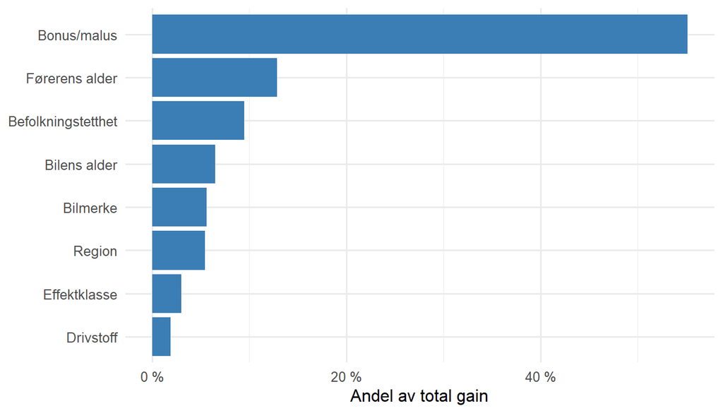

Figur 8: Variabelviktighet i GBM-en, som andel av total gain. Dummyvariablene for de kategoriske variablene er summert.

```r
imp <- gbm_res$importance |>
  mutate(label = unname(gbm_labels[variable]))

ggplot(imp, aes(x = Gain, y = reorder(label, Gain))) +
  geom_col(fill = fill_col) +
  scale_x_continuous(labels = function(x) pct(x, 0)) +
  labs(x = "Andel av total gain", y = NULL)
```

Bonus/malus står alene for 55 % av den totale gainen, og førerens alder er nest viktigst med 13 % (Figur 8). Det stemmer med F-testene for GLM-en, der de samme to var viktigst.

Gain bør likevel tolkes med forsiktighet. Kontinuerlige variabler med mange mulige splittpunkter, som tetthet, kan få høy gain bare fordi trærne har mange måter å bruke dem på. Variabler som henger sammen, som alder og bonus/malus, deler dessuten på æren, slik at fordelingen mellom dem blir noe tilfeldig.

#### 5.6.3 Effekten av alder og bonus/malus

**Kode**

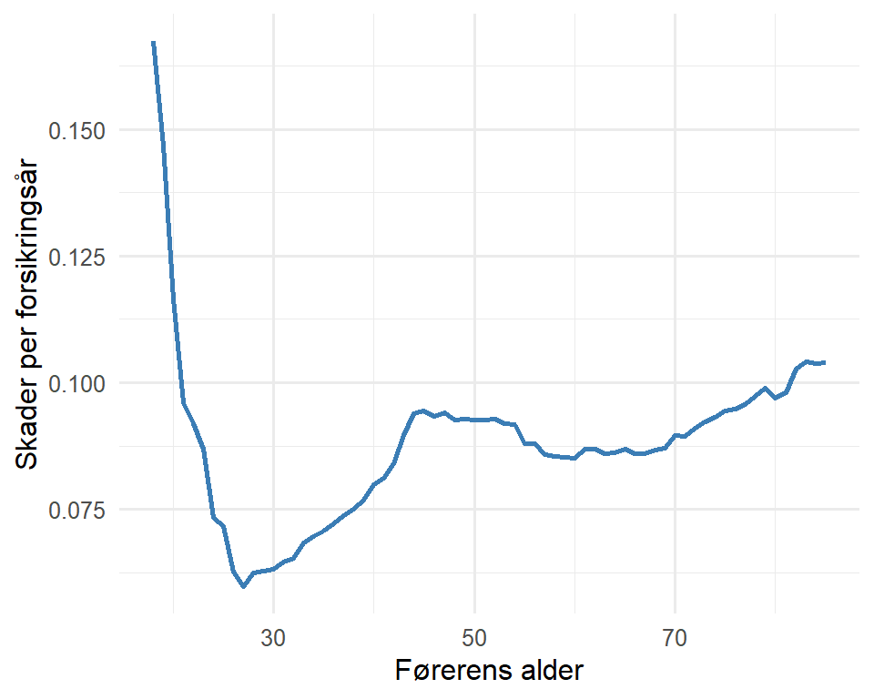

(a) Førerens alder

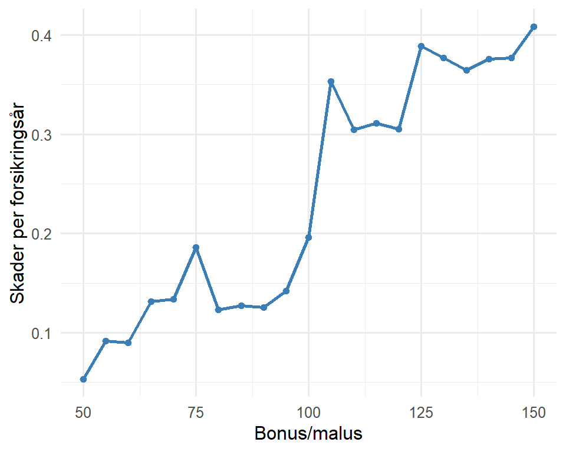

(b) Bonus/malus

Figur 9: Partial dependence: gjennomsnittlig predikert skadefrekvens per forsikringsår i GBM-en, når én variabel settes til samme verdi for alle.

```r
ggplot(gbm_res$pd_age, aes(DrivAge, frekvens)) +
  geom_line(colour = fill_col, linewidth = 1) +
  labs(x = "Førerens alder", y = "Skader per forsikringsår")

ggplot(gbm_res$pd_bm, aes(BonusMalus, frekvens)) +
  geom_line(colour = fill_col, linewidth = 1) +
  geom_point(colour = fill_col) +
  labs(x = "Bonus/malus", y = "Skader per forsikringsår")
```

**Kode**

```r
pd_age  <- gbm_res$pd_age
pd_bm   <- gbm_res$pd_bm
pd_a    <- function(a) pd_age$frekvens[pd_age$DrivAge == a]
pd_b    <- function(b) pd_bm$frekvens[pd_bm$BonusMalus == b]
age_min <- pd_age$DrivAge[which.min(pd_age$frekvens)]
```

Partial dependence-kurvene kan sammenlignes med de relative risikoene fra GLM-en (Figur 9):

- **Alder:** Frekvensen er 0,167 for en 18-åring og lavest ved 27 år (0,060), altså 2,8 ganger så høy for de yngste når de andre variablene holdes like. Deretter øker den igjen, til 0,094 ved 45 år og 0,104 ved 85 år. Mønsteret er det samme som i GLM-en, som fant lavest risiko for 27–31 år og høyere for 42–51 år. GBM-en bruker alder som kontinuerlig variabel og er ikke avhengig av at grupperingen er valgt riktig på forhånd, men den bekrefter at grupperingen i GLM-en fanger hovedtrekkene.
- **Bonus/malus:** Frekvensen ved 100 er 3,7 ganger så høy som ved 50, mot en relativ risiko på 3,28 for gruppen 81–100 i GLM-en. Kurven er likevel ikke monoton: frekvensen er 0,186 ved 75, men bare 0,123 ved 80, og 0,353 ved 105 mot 0,305 ved 110. Bonus/malus er ikke jevnt fordelt, siden nivået endres i faste steg i det franske systemet. For eksempel har 1 067 forsikringer i treningssettet nøyaktig 75, mot 14 550 med 80. Der det er få forsikringer, kan trærne tilpasse seg tilfeldig støy. Over 125 er det også få forsikringer (0,12 % av treningssettet), så den delen av kurven er usikker.

En pris som går ned når bonus/malus øker, ville vært vanskelig å forsvare overfor kundene. Dette er et konkret eksempel på hvorfor en GBM ikke kan brukes direkte til prising uten videre kontroll.

#### 5.6.4 Samspill mellom alder og bonus/malus

**Kode**

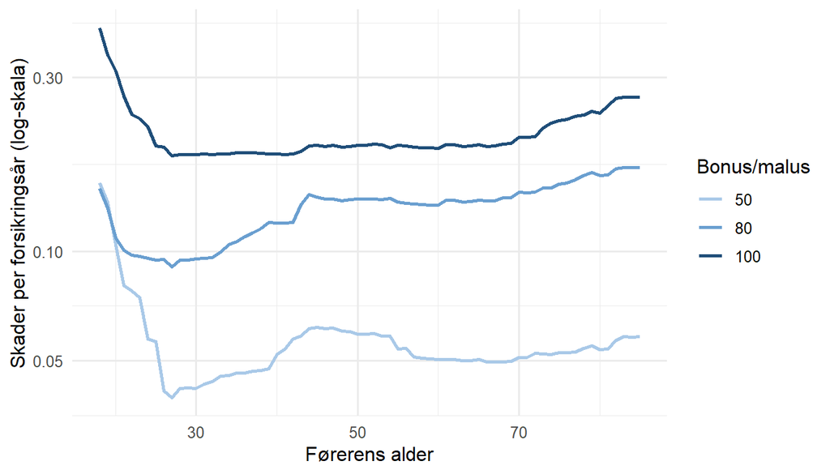

Figur 10: Partial dependence for førerens alder ved tre bonus/malus-nivåer. Logaritmisk skala: parallelle kurver betyr at det ikke er samspill, slik GLM-en antar.

```r
ggplot(gbm_res$pd_age_bm,
       aes(DrivAge, frekvens, colour = factor(BonusMalus))) +
  geom_line(linewidth = 1) +
  scale_y_log10() +
  scale_colour_manual(values = c("50" = "#A9C9E8", "80" = "#6A9FD0", "100" = "#1F4E79")) +
  labs(x = "Førerens alder", y = "Skader per forsikringsår (log-skala)",
       colour = "Bonus/malus")
```

**Kode**

```r
pd_ab <- gbm_res$pd_age_bm
pd_at <- function(b, a) pd_ab$frekvens[pd_ab$BonusMalus == b & pd_ab$DrivAge == a]
r80  <- pd_at(80, 25) / pd_at(80, 50)
r100 <- pd_at(100, 25) / pd_at(100, 50)
# GLM-ens forhold mellom tilsvarende aldersgrupper, likt for alle bonus/malus-nivåer
r_glm <- get_rr("DrivAgeGrouped", "22–26")$rr / get_rr("DrivAgeGrouped", "42–51")$rr
n_young_full <- sum(train$DrivAge < 30 & train$BonusMalus == 50)
```

Hvis effekten av alder var uavhengig av bonus/malus, ville kurvene i Figur 10 vært parallelle på log-skala. GLM-en antar nettopp det: der er forholdet mellom aldersgruppene 22–26 og 42–51 år 0,66, uansett bonus/malus-nivå. I GBM-en er forholdet mellom en 25-åring og en 50-åring 0,68 ved bonus/malus 80, men 1,00 ved bonus/malus 100. Kurvene har altså ulik form, og effekten av alder avhenger av bonus/malus-nivået.

Det stemmer med tolkningen fra GLM-en. En 25-åring med bonus/malus 80 har trolig vært skadefri siden førerkortet, mens en 50-åring på samme nivå sannsynligvis har hatt skader. Ved bonus/malus 100 har derimot begge enten nettopp startet eller hatt skader, og risikoen er nesten lik. Samme bonus/malus-nivå betyr altså ulike ting i ulike aldre, og GLM-en uten samspillsledd fanger ikke opp dette.

Kurven for bonus/malus 50 må leses med forsiktighet for unge førere. Nye førere starter på 100, og nivået synker med omtrent 5 % per skadefritt år, så det tar rundt 14 år å nå 50. Bare 2 161 forsikringer i treningssettet har en fører under 30 år med bonus/malus 50. Her ekstrapolerer modellen til kombinasjoner som nesten ikke finnes i dataene. Det er en generell svakhet ved partial dependence når variablene henger sammen.

#### 5.6.5 Kalibrering

**Kode**

[figure not shown]

(a) Førerens alder

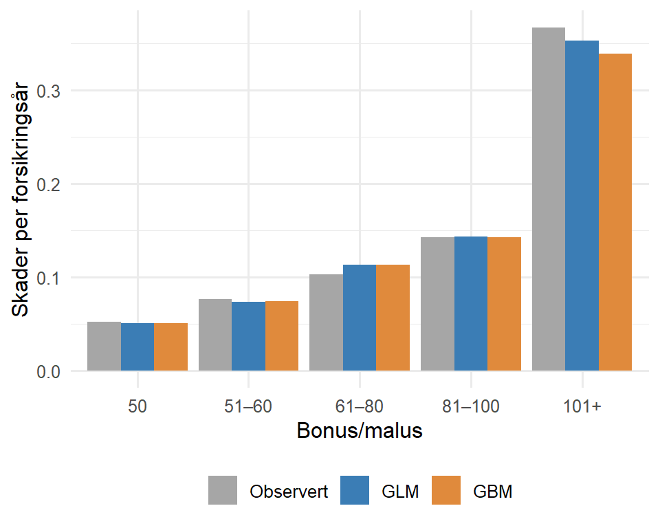

(b) Bonus/malus

Figur 11: Observert og predikert skadefrekvens på testdata for GLM og GBM.

```r
plot_cal <- function(glm_cal, gbm_cal, lev, xlab) {
  d <- data.frame(
    gruppe   = factor(rep(glm_cal$level, 3), levels = lev),
    type     = factor(rep(c("Observert", "GLM", "GBM"), each = nrow(glm_cal)),
                      levels = c("Observert", "GLM", "GBM")),
    frekvens = c(glm_cal$observert, glm_cal$predikert, gbm_cal$predikert)
  )
  ggplot(d, aes(gruppe, frekvens, fill = type)) +
    geom_col(position = "dodge") +
    scale_fill_manual(values = c(Observert = "grey65", GLM = fill_col, GBM = "#E08A3C")) +
    labs(x = xlab, y = "Skader per forsikringsår", fill = NULL) +
    theme(legend.position = "bottom")
}

plot_cal(glm_res$calibration$age, gbm_res$calibration$age,
         levels(train$DrivAgeGrouped), "Førerens alder")
plot_cal(glm_res$calibration$bonus_malus, gbm_res$calibration$bonus_malus,
         levels(train$BonusMalusGrouped), "Bonus/malus")
```

**Kode**

```r
max_dev <- function(cal) max(abs(cal$predikert / cal$observert - 1))
malus_dev <- function(cal) {
  r <- cal[cal$level == "101+", ]
  r$predikert / r$observert - 1
}
gbm_total_dev <- gbm_res$totals[["predikert"]] / gbm_res$totals[["observert"]] - 1
```

## 6 Diskusjon

### 6.1 Hva GBM-en tilfører

GBM-en predikerer bedre enn GLM-en, men forbedringen er moderat: deviansen på test er 1,7 % lavere. Det viktigste bidraget er at den viser *hvor* GLM-en kommer til kort. Partial dependence-kurvene bekrefter at grupperingen av alder fanger hovedtrekkene, mens samspillsanalysen viser at effekten av alder avhenger av bonus/malus-nivået. Det er trolig en stor del av forklaringen på at GBM-en er bedre.

### 6.2 Hvorfor GLM-en fortsatt er førstevalget for prising

Selv om GBM-en predikerer bedre, har GLM-en flere fordeler i praksis:

- **Tolkbarhet:** Prisen kan skrives som en grunnpris ganget med én faktor per kjennetegn. Hver faktor kan leses direkte og forklares til kunder, ledelse og tilsynsmyndigheter. GBM-en består av 527 trær.
- **Kontroll:** Aktuaren kan justere og glatte faktorene, for eksempel for å sikre at prisen alltid øker med bonus/malus. GBM-en gir en bonus/malus-kurve som ikke er monoton, og predikerer for lavt for kundene med malus.
- **Stabilitet:** Effektene i en GLM endrer seg lite fra år til år når modellen tilpasses på nytt. Det er viktig for kundene, som ikke bør få store prisendringer uten at noe ved dem har endret seg.

En vanlig arbeidsdeling er derfor å bruke maskinlæring til å finne ikke-lineære effekter og samspill, og så legge de viktigste av dem inn i GLM-en som egne ledd.

### 6.3 Begrensninger

- **Overdispersjon:** Den anslåtte dispersjonen på 1,72 viser at det finnes variasjon mellom kundene som variablene ikke fanger opp. Den viktigste manglende variabelen er trolig hvor mye kunden kjører. Quasi-Poisson justerer standardfeilene, men endrer ikke prediksjonene.
- **Bonus/malus bygger på skadehistorikken.** Variabelen er den sterkeste i begge modellene, men den sier lite om nye kunder uten historikk. Den gjør også at effekten av alder må tolkes betinget på bonus/malus, slik samspillsanalysen viste.
- **Tilfeldig splitt:** Testsettet er trukket tilfeldig fra samme periode som treningssettet. I praksis brukes modellen til å prise neste år, og en test på data fra et senere år ville gitt et mer realistisk bilde. Datasettet har ingen tidsvariabel, så det er ikke mulig her.
- **Bare skadefrekvens:** Prisen avhenger også av hvor mye hver skade koster. Grupperingene i GLM-en er dessuten valgt manuelt ut fra EDA-en, og andre valg kunne gitt litt andre resultater.

### 6.4 Videre arbeid

- Legge inn et samspillsledd mellom alder og bonus/malus i GLM-en, og teste med en F-test om det forbedrer modellen. Det er det mest naturlige neste steget, siden GBM-en tyder på at samspillet er reelt.
- Bruke monotonibetingelser i xgboost, slik at frekvensen alltid øker med bonus/malus, og se hvor mye det koster i prediksjonsevne.
- Erstatte quasi-Poisson med en negativ binomisk modell, som modellerer overdispersjonen eksplisitt.
- Modellere skadestørrelse, for eksempel med en gamma-GLM på datasettet `freMTPL2sev` fra samme pakke, og kombinere med frekvensmodellen til en risikopremie.

## 7 Konklusjon

Bonus/malus og førerens alder er de viktigste forklaringsvariablene for skadefrekvens i dette datasettet. Den fulle Poisson-GLM-en reduserer devians på testdata med 4,6 % sammenlignet med en modell der alle har samme frekvens, og den er godt kalibrert både totalt og per aldersgruppe. Når alder og bonus/malus er med samtidig, blir alderseffekten mye mindre enn EDA-en antydet, fordi unge førere også har høy bonus/malus.

Gradient boosting reduserer devians med 6,2 % og viser at effekten av alder avhenger av bonus/malus-nivået. Samtidig gir den en bonus/malus-effekt som ikke er monoton, og den er langt vanskeligere å tolke og kontrollere. Det beste valget for prising er derfor trolig en GLM utvidet med et samspillsledd mellom alder og bonus/malus, der GBM-en brukes som verktøy for å finne slike forbedringer.

## 8 Referanser

Chen, T. og Guestrin, C. (2016). XGBoost: A scalable tree boosting system. *Proceedings of the 22nd ACM SIGKDD International Conference on Knowledge Discovery and Data Mining*, 785–794.

Friedman, J. H. (2001). Greedy function approximation: A gradient boosting machine. *The Annals of Statistics*, 29(5), 1189–1232.

Noll, A., Salzmann, R. og Wüthrich, M. V. (2018). *Case Study: French Motor Third-Party Liability Claims*. SSRN.